# Visualisasi Data dengan `ggplot2`

## 3.2 Aesthetic mapping

### 3.2.1 Updating based on a constant? NO `aes()`!

To change aesthetics of a graph based on a constant (e.g. “Make all the points BLUE”), we can add the information directly to the relevant `geom_` layer. Some things to keep in mind:

- `fill`: updates fill colors (e.g. column, density, violin, & boxplot interior fill color)
- `color`: updates point & border line colors (generally)
- `shape`: update point style
- `alpha`: update transparency (0 = transparent, 1 = opaque)
- `size`: point size or line width
- `linetype`: update the line type (e.g. “dotted”, “dashed”, “dotdash”, etc.)

If you are updating these by referring to a constant value, they **should not be within an `aes()`**.

For example, let’s make some nightmares:

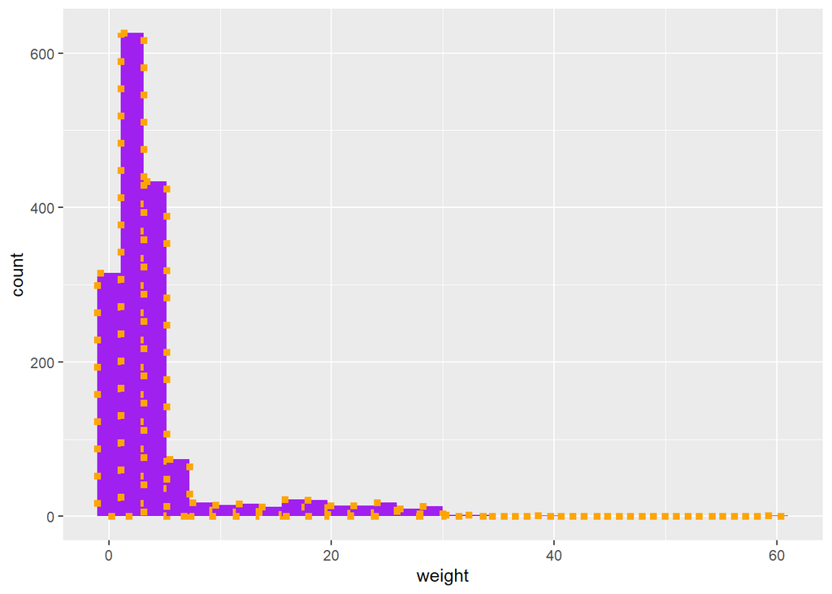

```r
ggplot(data = lizards, aes(x = weight)) +
  geom_histogram(color = "orange",
                 fill = "purple",
                 size = 2,
                 linetype = "dotted")
```

Some shapes have both a fill and color aesthetic:

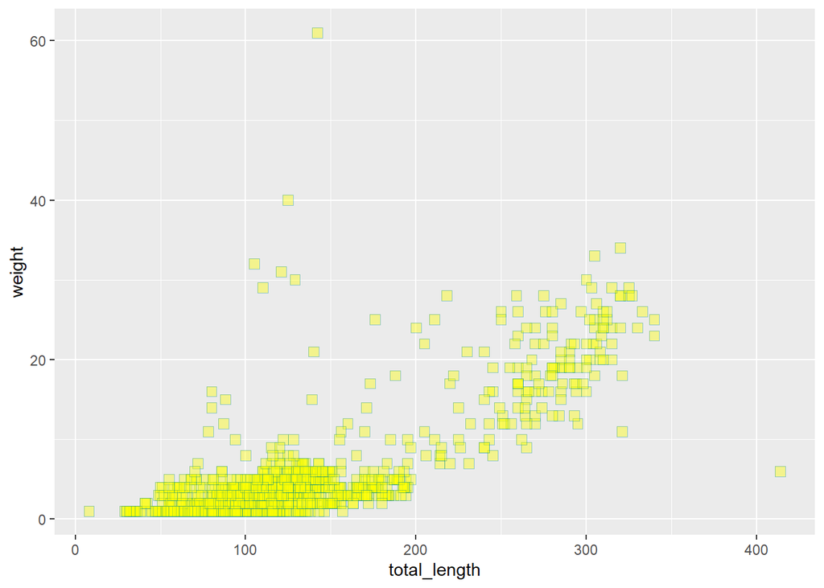

```r
ggplot(data = lizards, aes(x = total_length, y = weight)) +
  geom_point(color = "cyan4",
             fill = "yellow",
             shape = 22,
             size = 3,
             alpha = 0.4)
```

### 3.2.2 Updating an aesthetic based on a variable? YES `aes()`!

If you want to map a variable onto a graph aesthetic (e.g., point color should be based on *lizard species*), put it within `aes()`.

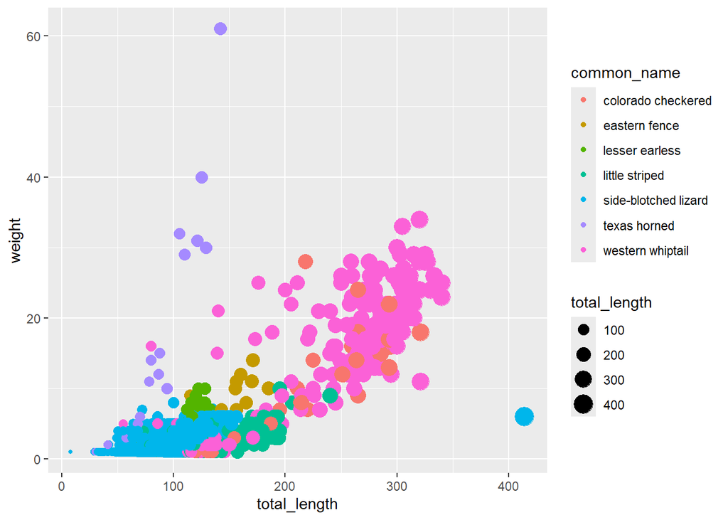

```r
ggplot(data = lizards, aes(x = total_length, y = weight)) +
  geom_point(aes(color = common_name, size = total_length))
```

These can be used in combination. For example, if we want the color to be based on species, but the transparency for all points is 0.3:

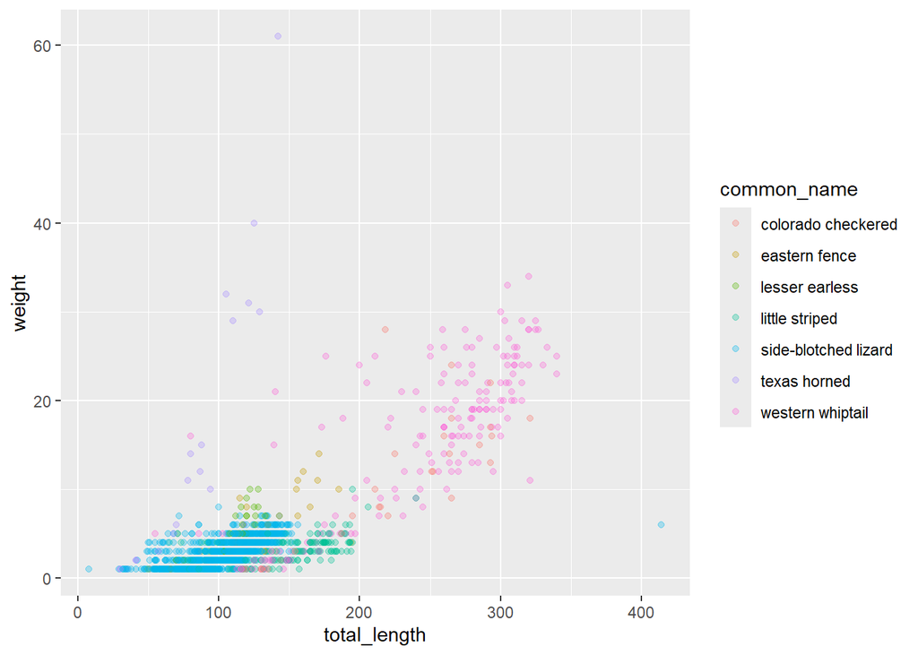

```r
ggplot(data = lizards, aes(x = total_length, y = weight)) +
  geom_point(aes(color = common_name), alpha = 0.3)
```

## 3.3 Themes

Quick reminder: yeah there are some built-in themes you can add with `+ theme_*()`.

A few useful baselines are:

- `theme_minimal()`: minimal theme
- `theme_bw()`: also pretty good for some stuff
- `theme_light()`: a nice light one

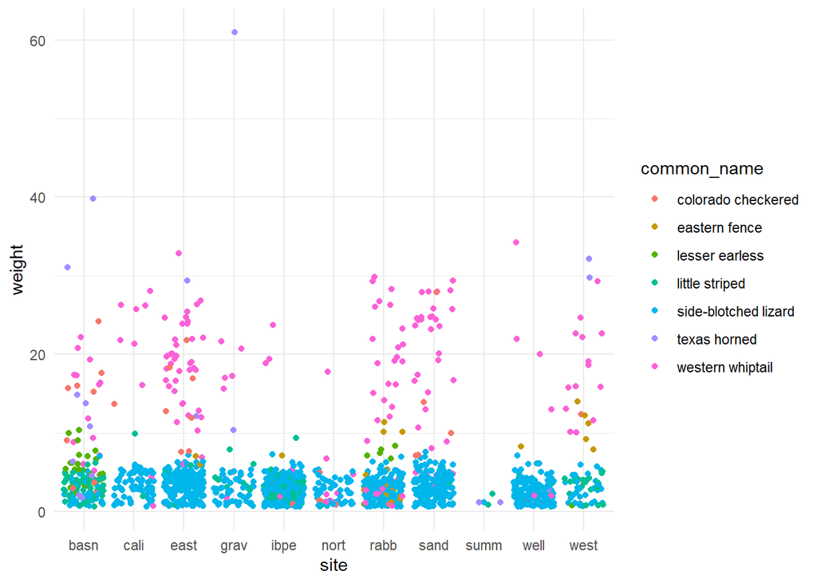

```r
ggplot(data = lizards, aes(x = site, y = weight)) +
  geom_jitter(aes(color = common_name)) +
  theme_minimal()
```

## 3.4 Axis labels

For basic axis labels, I recommend `labs()`:

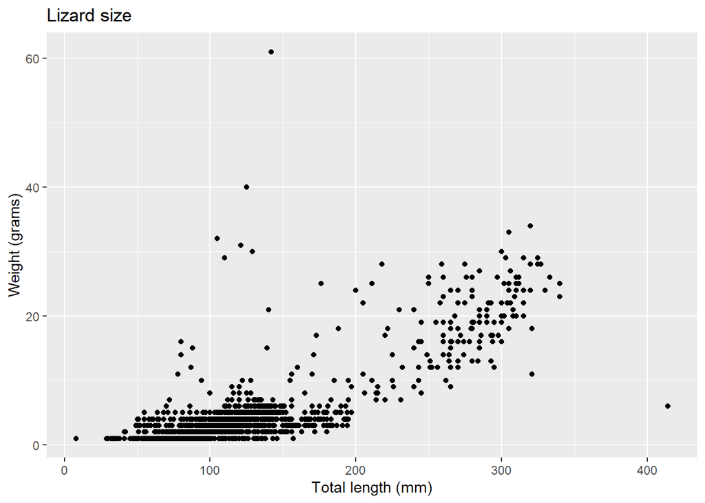

```r
ggplot(data = lizards, aes(x = total_length, y = weight)) +
  geom_point() +
  labs(x = "Total length (mm)",
       y = "Weight (grams)",
       title = "Lizard size")
```

We’ll learn a few more advanced label skills later on.

## 3.5 Facetting

Sometimes it’s useful to split up information in a graph into separate panels. For example, maybe we want to have a separate graph of total length versus weight for *each lizard species*. That would be really tedious to create them all manually from subsets. Instead, we’ll facet by distinct groups within a variable.

We’ll learn two ways to do this:

- `facet_wrap()`: the one where you give it one faceting variable and the panels get wrapped into a grid
- `facet_grid()`: the one where you make a grid based on row & column faceting variables

For example, let’s say we just want each species to have its own panel. Then we can use `facet_wrap()`:

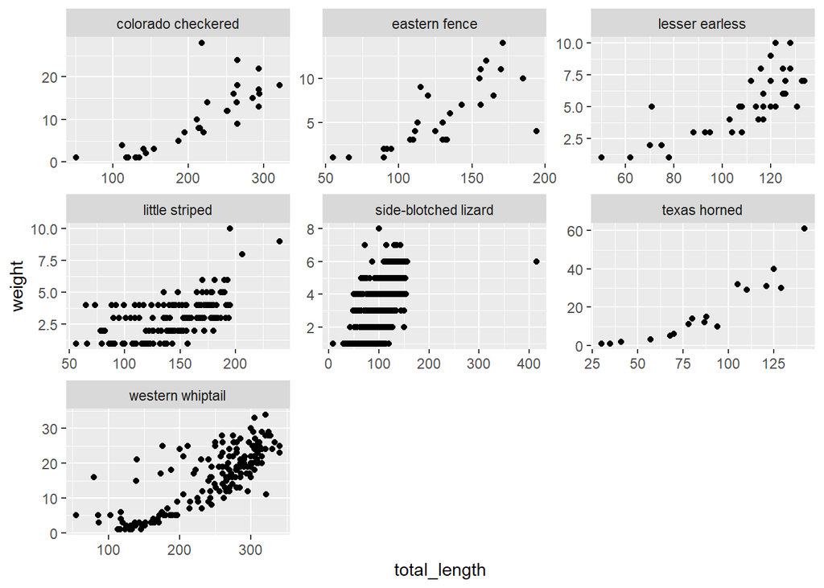

```r
ggplot(data = lizards, aes(x = total_length, y = weight)) +
  geom_point() +
  facet_wrap(~common_name, ncol = 3, scales = "free")
```

But what if we want to make a grid where the panels are split across groups by lizard sex and if it has a broken tail or not? Since we have two variables being used to create our grid, we’ll use `facet_grid()`:

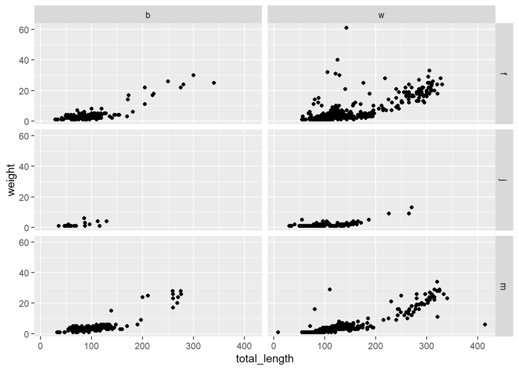

```r
ggplot(data = lizards, aes(x = total_length, y = weight)) +
  geom_point() +
  facet_grid(sex ~ tail)
```

## 3.6 Getting things in order

`ggplot` loves putting things in alphabetical order - but that’s rarely the order you actually want things in if you have categorical groups. Let’s find some total counts of lizards in the dataset by common name, then make a column graph:

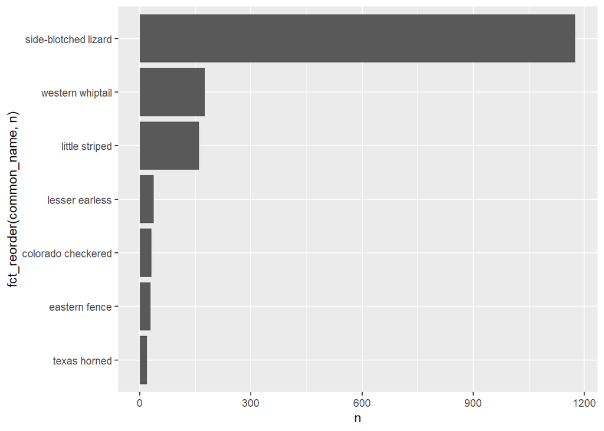

```r
lizard_counts <- lizards %>%
  count(common_name)

ggplot(data = lizard_counts, aes(y = fct_reorder(common_name, n), x = n)) +
  geom_col()
```

## 3.7 `ggplot` basics: synthesis examples

**Example 1:** A quick review of basics, including:

- `ggplot` essentials
- aesthetic mapping
- themes
- `facet_wrap` & `facet_grid`
- labels with `labs`

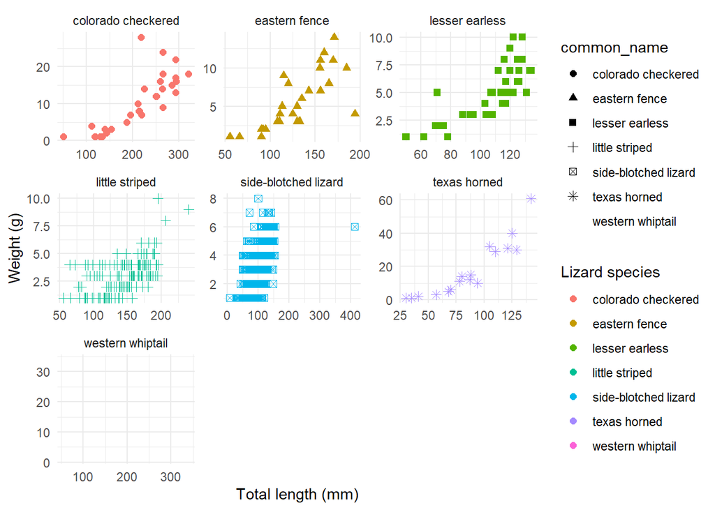

```r
ggplot(data = lizards, aes(x = total_length, y = weight)) +
  geom_point(aes(color = common_name, shape = common_name),
             fill = "black",
             size = 2) +
  theme_minimal() +
  labs(x = "Total length (mm)",
       y = "Weight (g)",
       color = "Lizard species") +
  facet_wrap(~common_name, scales = "free")
```

**Example 2:** Reminders of position, `facet_grid`, and factor reordering

Let’s make a stacked column graph of lizard species by site:

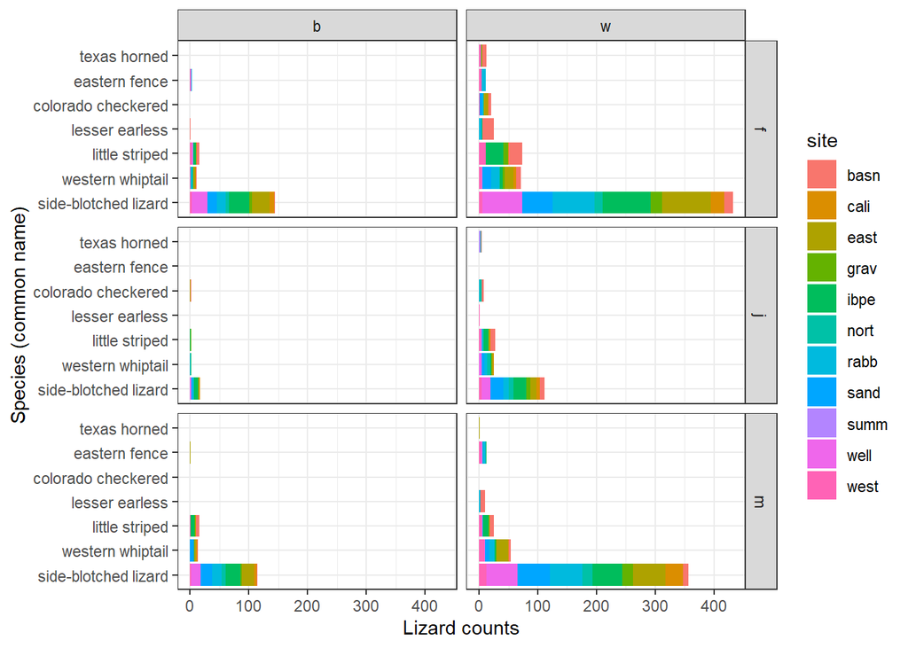

```r
ggplot(data = lizards, aes(y = fct_infreq(common_name))) +
  geom_bar(aes(fill = site)) +
  theme_bw() +
  labs(x = "Lizard counts",
       y = "Species (common name)") +
  facet_grid(sex ~ tail)
```

```r
# That annoying space below zero? Let's keep that in mind...
```

# 4 Advanced `ggplot2` customization

## 4.1 An unsung hero: `scales`

The [`scales`](https://scales.r-lib.org/index.html) package in R is truly an unsung hero of finalizing `ggplot` graphs. To hear more, I strongly recommend watching Dana Seidel’s 20 minute talk on [*The little package that could: Taking visualizations to the next level with the scales package*](https://rstudio.com/resources/rstudioconf-2020/the-little-package-that-could-taking-visualizations-to-the-next-level-with-the-scales-package/) from rstudio::conf(2020).

Why does that matter to us? *Because a whole lot of the subtle things that make a graph way better are updating using the scales suite of helpful functions.*

For a complete list of scales functions & usage, see: https://scales.r-lib.org/index.html

### 4.1.1 Thoughtful breaks, limits & labels

Little things make a big difference in data visualization. Just like we should take great care to make axis labels useful and complete, we also need to think about how values are communicated for our different variables.

In 2-D data visualization, that means customizing your breaks, limits, & tick mark labels & formatting. From Hadley Wickham & Dana Seidel: “The most common use of the `scales` package is to control the appearance of axis and legend labels. Use a `break_` function to control how breaks are generated from the limits, and a `label_` function to control how breaks are turned in to labels.”

Let’s explore some different ways to update breaks and labels.